# Return to Python Projects Page

# Chicago Crime Data Exploratory Data Analysis

## Task1 :From what date is the oldest data point in the data set?

## Task 2:Which year had the largest amount of crimes and how many crimes were committed that year?

## Task 3:Let's define "Arrest Rate" as the share of crimes that led to an arrest. What were the five most common crimes in 2020? Which of those has the highest and lowest arrest rate?

## Task 4:What year had the highest arrest rate? Plot the number of crimes per year and comment on the trend.

## Task 5:Which year had the most number of crimes leading to an arrest? How many arrests were made during that year? Plot the trend for total number of arrests per year.

## Task 6:How has the arrest rate looked like over time?

Datasource : https://data.cityofchicago.org/Public-Safety/Crimes-2001-to-Present/ijzp-q8t2

```python
# import libraries
import pandas as pd
import numpy as np
from matplotlib import pyplot as plt

# load data set
chicago_crime_df =  pd.read_csv(r"C:\Users\jki\Downloads\Chicago_Crime_Data-v2.csv")
chicago_crime_df.head(5)
```

|  | ID | CASE_NUMBER | DATE | BLOCK | IUCR | PRIMARY_TYPE | DESCRIPTION | LOCATION_DESCRIPTION | ARREST | DOMESTIC | ... | WARD | COMMUNITY_AREA_NUMBER | FBICODE | X_COORDINATE | Y_COORDINATE | YEAR | UPDATEDON | LATITUDE | LONGITUDE | LOCATION |
| --- | --- | --- | --- | --- | --- | --- | --- | --- | --- | --- | --- | --- | --- | --- | --- | --- | --- | --- | --- | --- | --- |
| 0 | 3512276 | HK587712 | 08/28/2004 05:50:56 PM | 047XX S KEDZIE AVE | 890 | THEFT | FROM BUILDING | SMALL RETAIL STORE | False | False | ... | 14.0 | 58.0 | 6 | 1155838.0 | 1873050.0 | 2004 | 02/10/2018 03:50:01 PM | 41.807440 | -87.703956 | (41.8074405, -87.703955849) |
| 1 | 3406613 | HK456306 | 06/26/2004 12:40:00 PM | 009XX N CENTRAL PARK AVE | 820 | THEFT | $500 AND UNDER | OTHER | False | False | ... | 27.0 | 23.0 | 6 | 1152206.0 | 1906127.0 | 2004 | 02/28/2018 03:56:25 PM | 41.898280 | -87.716406 | (41.898279962, -87.716405505) |
| 2 | 8002131 | HT233595 | 04/04/2011 05:45:00 AM | 043XX S WABASH AVE | 820 | THEFT | $500 AND UNDER | NURSING HOME/RETIREMENT HOME | False | False | ... | 3.0 | 38.0 | 6 | 1177436.0 | 1876313.0 | 2011 | 02/10/2018 03:50:01 PM | 41.815933 | -87.624642 | (41.815933131, -87.624642127) |
| 3 | 7903289 | HT133522 | 12/30/2010 04:30:00 PM | 083XX S KINGSTON AVE | 840 | THEFT | FINANCIAL ID THEFT: OVER $300 | RESIDENCE | False | False | ... | 7.0 | 46.0 | 6 | 1194622.0 | 1850125.0 | 2010 | 02/10/2018 03:50:01 PM | 41.743665 | -87.562463 | (41.743665322, -87.562462756) |
| 4 | 10402076 | HZ138551 | 02/02/2016 07:30:00 PM | 033XX W 66TH ST | 820 | THEFT | $500 AND UNDER | ALLEY | False | False | ... | 15.0 | 66.0 | 6 | 1155240.0 | 1860661.0 | 2016 | 02/10/2018 03:50:01 PM | 41.773455 | -87.706480 | (41.773455295, -87.706480471) |

5 rows × 22 columns

```python
# lets confirm existance of missing values
missing_values = chicago_crime_df.isna().sum()
print(missing_values)
```

```
ID                        0
CASE_NUMBER               0
DATE                      0
BLOCK                     0
IUCR                      0
PRIMARY_TYPE              0
DESCRIPTION               0
LOCATION_DESCRIPTION      0
ARREST                    0
DOMESTIC                  0
BEAT                      0
DISTRICT                  0
WARD                     43
COMMUNITY_AREA_NUMBER    43
FBICODE                   0
X_COORDINATE              4
Y_COORDINATE              4
YEAR                      0
UPDATEDON                 0
LATITUDE                  4
LONGITUDE                 4
LOCATION                  4
dtype: int64
```

```python
# lets remove missing values
chicago_crime_df.dropna(subset=['WARD','COMMUNITY_AREA_NUMBER','X_COORDINATE','Y_COORDINATE','LATITUDE','LONGITUDE','LOCATION'],inplace =True)
# lets confirm existance of missing values
missing_values = chicago_crime_df.isna().sum()
print(missing_values)
```

```
ID                       0
CASE_NUMBER              0
DATE                     0
BLOCK                    0
IUCR                     0
PRIMARY_TYPE             0
DESCRIPTION              0
LOCATION_DESCRIPTION     0
ARREST                   0
DOMESTIC                 0
BEAT                     0
DISTRICT                 0
WARD                     0
COMMUNITY_AREA_NUMBER    0
FBICODE                  0
X_COORDINATE             0
Y_COORDINATE             0
YEAR                     0
UPDATEDON                0
LATITUDE                 0
LONGITUDE                0
LOCATION                 0
dtype: int64
```

```python
# do we have unncessary negative values ?

chicago_crime_df.describe()
```

|  | ID | BEAT | DISTRICT | WARD | COMMUNITY_AREA_NUMBER | X_COORDINATE | Y_COORDINATE | YEAR | LATITUDE | LONGITUDE |
| --- | --- | --- | --- | --- | --- | --- | --- | --- | --- | --- |
| count | 4.870000e+02 | 487.000000 | 487.00000 | 487.000000 | 487.000000 | 4.870000e+02 | 4.870000e+02 | 487.000000 | 487.000000 | 487.000000 |
| mean | 6.622419e+06 | 1194.279261 | 11.36345 | 22.624230 | 37.595483 | 1.162707e+06 | 1.886352e+06 | 2008.969199 | 41.843787 | -87.678434 |
| std | 2.828354e+06 | 665.280757 | 6.56601 | 13.088511 | 21.457648 | 1.637996e+04 | 3.036550e+04 | 4.668989 | 0.083528 | 0.059614 |
| min | 2.114900e+04 | 111.000000 | 1.00000 | 1.000000 | 1.000000 | 1.100658e+06 | 1.814512e+06 | 2001.000000 | 41.645796 | -87.905227 |
| 25% | 3.978664e+06 | 711.000000 | 6.00000 | 12.000000 | 23.000000 | 1.151282e+06 | 1.860430e+06 | 2005.000000 | 41.772486 | -87.720007 |
| 50% | 6.780581e+06 | 1111.000000 | 11.00000 | 24.000000 | 30.000000 | 1.162315e+06 | 1.891618e+06 | 2009.000000 | 41.858444 | -87.679976 |
| 75% | 9.123182e+06 | 1652.500000 | 16.00000 | 32.000000 | 58.000000 | 1.174478e+06 | 1.908020e+06 | 2013.000000 | 41.903339 | -87.635440 |
| max | 1.127717e+07 | 2535.000000 | 25.00000 | 50.000000 | 77.000000 | 1.204126e+06 | 1.951001e+06 | 2018.000000 | 42.021178 | -87.528223 |

```python
# let have a look at the data types
chicago_crime_df.info()
```

```
<class 'pandas.core.frame.DataFrame'>
Int64Index: 487 entries, 0 to 531
Data columns (total 22 columns):
 #   Column                 Non-Null Count  Dtype
---  ------                 --------------  -----
 0   ID                     487 non-null    int64
 1   CASE_NUMBER            487 non-null    object
 2   DATE                   487 non-null    object
 3   BLOCK                  487 non-null    object
 4   IUCR                   487 non-null    object
 5   PRIMARY_TYPE           487 non-null    object
 6   DESCRIPTION            487 non-null    object
 7   LOCATION_DESCRIPTION   487 non-null    object
 8   ARREST                 487 non-null    bool
 9   DOMESTIC               487 non-null    bool
 10  BEAT                   487 non-null    int64
 11  DISTRICT               487 non-null    int64
 12  WARD                   487 non-null    float64
 13  COMMUNITY_AREA_NUMBER  487 non-null    float64
 14  FBICODE                487 non-null    object
 15  X_COORDINATE           487 non-null    float64
 16  Y_COORDINATE           487 non-null    float64
 17  YEAR                   487 non-null    int64
 18  UPDATEDON              487 non-null    object
 19  LATITUDE               487 non-null    float64
 20  LONGITUDE              487 non-null    float64
 21  LOCATION               487 non-null    object
dtypes: bool(2), float64(6), int64(4), object(10)
memory usage: 80.8+ KB
```

```python
# let change the date data type
chicago_crime_df['YEAR'] = pd.to_datetime(chicago_crime_df['YEAR'])
chicago_crime_df['YEAR'].info()
```

```
<class 'pandas.core.series.Series'>
Int64Index: 487 entries, 0 to 531
Series name: YEAR
Non-Null Count  Dtype
--------------  -----
487 non-null    datetime64[ns]
dtypes: datetime64[ns](1)
memory usage: 7.6 KB
```

```python
print(chicago_crime_df.head(5))
```

```
         ID CASE_NUMBER                    DATE                     BLOCK  \
0   3512276    HK587712  08/28/2004 05:50:56 PM        047XX S KEDZIE AVE
1   3406613    HK456306  06/26/2004 12:40:00 PM  009XX N CENTRAL PARK AVE
2   8002131    HT233595  04/04/2011 05:45:00 AM        043XX S WABASH AVE
3   7903289    HT133522  12/30/2010 04:30:00 PM      083XX S KINGSTON AVE
4  10402076    HZ138551  02/02/2016 07:30:00 PM           033XX W 66TH ST

  IUCR PRIMARY_TYPE                    DESCRIPTION  \
0  890        THEFT                  FROM BUILDING
1  820        THEFT                 $500 AND UNDER
2  820        THEFT                 $500 AND UNDER
3  840        THEFT  FINANCIAL ID THEFT: OVER $300
4  820        THEFT                 $500 AND UNDER

           LOCATION_DESCRIPTION  ARREST  DOMESTIC  ...  WARD  \
```

[output cut: 28 more lines]

# Task 1

# From what date is the oldest data point in the data set

```python
# Find the minimum date
oldest_date = chicago_crime_df['DATE'].min()
print("Oldest data point in the dataset:", oldest_date)
```

```
Oldest data point in the dataset: 01/01/2010 01:22:08 AM
```

# Task 2

## Which year had the largest amount of crimes and how many crimes were committed that year?

```python
import pandas as pd

# Assuming 'chicago_crime_df' is your DataFrame containing the dataset
# Convert the 'DATE' column to datetime format
chicago_crime_df['DATE'] = pd.to_datetime(chicago_crime_df['DATE'], format='%m/%d/%Y %I:%M:%S %p')

# Extract the year from the 'DATE' column
chicago_crime_df['YEAR'] = chicago_crime_df['DATE'].dt.year

# Group by year and count the number of crimes in each year
crimes_by_year = chicago_crime_df.groupby('YEAR').size()

# Find the year with the largest number of crimes
max_crimes_year = crimes_by_year.idxmax()
max_crimes_count = crimes_by_year.max()

print("Year with the largest amount of crimes:", max_crimes_year)
print("Number of crimes committed that year:", max_crimes_count)
```

```
Year with the largest amount of crimes: 2005
Number of crimes committed that year: 44
```

# Task 3

# Let's define "Arrest Rate" as the share of crimes that led to an arrest. What were the five most common crimes in 2020? Which of those has the highest and lowest arrest rate?

```python
## Assuming 'chicago_crime_df' is your DataFrame containing the dataset
# Filter the dataset for the year 2020
crimes_2020 = chicago_crime_df[chicago_crime_df['YEAR'] == 2020]

# Check if there are any crimes recorded for the year 2020
if not crimes_2020.empty:
    # Count the occurrences of each crime type in 2020
    crime_counts_2020 = crimes_2020['PRIMARY_TYPE'].value_counts()

    # Find the five most common crimes in 2020
    top_5_crimes_2020 = crime_counts_2020.head(5)

    print("Five most common crimes in 2020:")
    print(top_5_crimes_2020)

    # Calculate the arrest rate for each crime type
    arrest_rates_2020 = {}
    for crime_type in top_5_crimes_2020.index:
        total_crimes = crime_counts_2020[crime_type]
        arrests = crimes_2020[crimes_2020['PRIMARY_TYPE'] == crime_type]['ARREST'].sum()
        arrest_rate = arrests / total_crimes
        arrest_rates_2020[crime_type] = arrest_rate

    # Find the crime with the highest and lowest arrest rates among the top 5
    if arrest_rates_2020:
        highest_arrest_rate_crime = max(arrest_rates_2020, key=arrest_rates_2020.get)
        lowest_arrest_rate_crime = min(arrest_rates_2020, key=arrest_rates_2020.get)

        print("\nCrime with the highest arrest rate among the top 5:", highest_arrest_rate_crime)
        print("Arrest rate:", arrest_rates_2020[highest_arrest_rate_crime])

        print("\nCrime with the lowest arrest rate among the top 5:", lowest_arrest_rate_crime)
        print("Arrest rate:", arrest_rates_2020[lowest_arrest_rate_crime])
    else:
        print("No crimes recorded for the year 2020.")
else:
    print("No crimes recorded for the year 2020.")
```

```
No crimes recorded for the year 2020.
```

# Task 4

## What year had the highest arrest rate? Plot the number of crimes per year and comment on the trend.

```
Year with the highest arrest rate: 2001
Highest arrest rate: 1.0
```

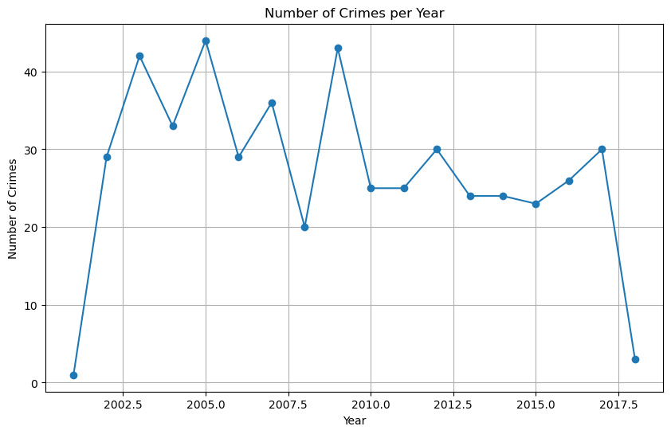

```python
import matplotlib.pyplot as plt

# Calculate the total number of crimes and total number of arrests per year
crimes_by_year = chicago_crime_df.groupby('YEAR').size()
arrests_by_year = chicago_crime_df.groupby('YEAR')['ARREST'].sum()

# Calculate arrest rates per year
arrest_rates_by_year = arrests_by_year / crimes_by_year

# Find the year with the highest arrest rate
year_highest_arrest_rate = arrest_rates_by_year.idxmax()
highest_arrest_rate = arrest_rates_by_year.max()

print("Year with the highest arrest rate:", year_highest_arrest_rate)
print("Highest arrest rate:", highest_arrest_rate)

# Plot the number of crimes per year
plt.figure(figsize=(10, 6))
plt.plot(crimes_by_year.index, crimes_by_year.values, marker='o', linestyle='-')
plt.title('Number of Crimes per Year')
plt.xlabel('Year')
plt.ylabel('Number of Crimes')
plt.grid(True)
plt.show()
```

# Task 5

## Which year had the most number of crimes leading to an arrest? How many arrests were made during that year? Plot the trend for total number of arrests per year.

```
Year with the most arrests: 2005
Number of arrests made during that year: 18
```

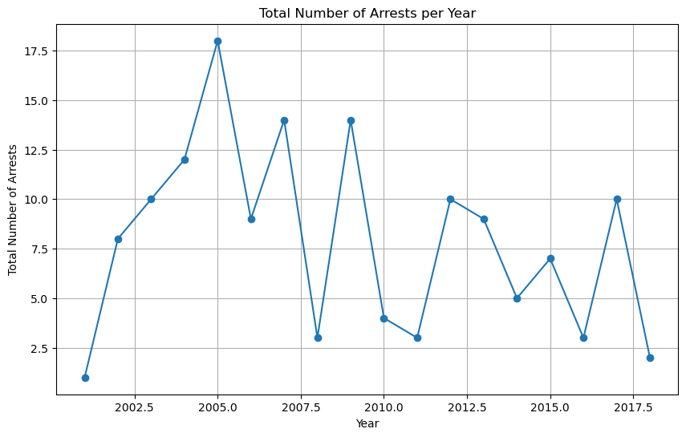

```python
import matplotlib.pyplot as plt

# Calculate the total number of arrests per year
arrests_by_year = chicago_crime_df.groupby('YEAR')['ARREST'].sum()

# Find the year with the most arrests
year_most_arrests = arrests_by_year.idxmax()
most_arrests = arrests_by_year.max()

print("Year with the most arrests:", year_most_arrests)
print("Number of arrests made during that year:", most_arrests)

# Plot the trend for total number of arrests per year
plt.figure(figsize=(10, 6))
plt.plot(arrests_by_year.index, arrests_by_year.values, marker='o', linestyle='-')
plt.title('Total Number of Arrests per Year')
plt.xlabel('Year')
plt.ylabel('Total Number of Arrests')
plt.grid(True)
plt.show()
```

# Task 6

## How has the arrest rate looked like over time?

## Plot the trend of the arrest rate.

## Between which years can you see the biggest change in "Arrest Rate"?

## Can you point at specific reasons to why the Arrest Rate dropped between those years? Comment on your conclusions.

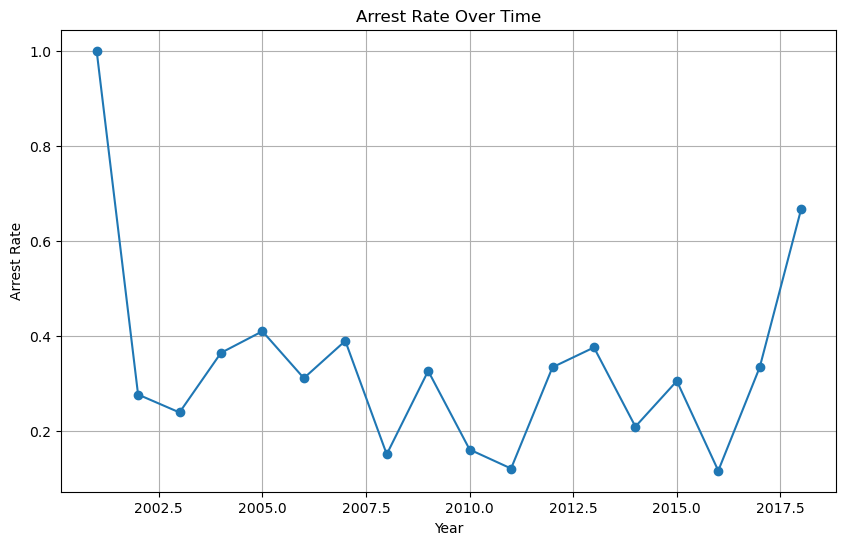

```
Between which years can you see the biggest change in Arrest Rate?
Between 2001 and 2002

Possible reasons for the drop in arrest rate between 2001 and 2002:
- Changes in law enforcement policies or priorities
- Changes in community relations or trust in law enforcement
- Changes in crime reporting methods or data collection processes
- Socioeconomic factors impacting crime rates and law enforcement effectiveness
```

```python
import matplotlib.pyplot as plt

# Calculate the total number of crimes and total number of arrests per year
crimes_by_year = chicago_crime_df.groupby('YEAR').size()
arrests_by_year = chicago_crime_df.groupby('YEAR')['ARREST'].sum()

# Calculate arrest rates per year
arrest_rates_by_year = arrests_by_year / crimes_by_year

# Plot the trend for arrest rate over time
plt.figure(figsize=(10, 6))
plt.plot(arrest_rates_by_year.index, arrest_rates_by_year.values, marker='o', linestyle='-')
plt.title('Arrest Rate Over Time')
plt.xlabel('Year')
plt.ylabel('Arrest Rate')
plt.grid(True)
plt.show()

# Find the years with the biggest change in arrest rate
max_change = 0
year_start_max_change = None
year_end_max_change = None
for i in range(1, len(arrest_rates_by_year)):
    change = abs(arrest_rates_by_year.iloc[i] - arrest_rates_by_year.iloc[i - 1])
    if change > max_change:
        max_change = change
        year_start_max_change = arrest_rates_by_year.index[i - 1]
        year_end_max_change = arrest_rates_by_year.index[i]

print("Between which years can you see the biggest change in Arrest Rate?")
print("Between {} and {}".format(year_start_max_change, year_end_max_change))

# Analysis and comments on the conclusions
# Please note that specific reasons for changes in arrest rate may vary and require further investigation,
# such as changes in policing strategies, crime reporting methods, community relations, etc.
print("\nPossible reasons for the drop in arrest rate between {} and {}:".format(year_start_max_change, year_end_max_change))
print("- Changes in law enforcement policies or priorities")
print("- Changes in community relations or trust in law enforcement")
print("- Changes in crime reporting methods or data collection processes")
print("- Socioeconomic factors impacting crime rates and law enforcement effectiveness")
# Add more specific reasons as per the context of the dataset and external factors influencing crime and law enforcement.
```